# Final Project

# **Correlation Between Temperature Change and Precipitation in the US**

Finally we need to see if there is any correlation between the precipitation increase and the temperature change. As seen before, there is an increase in temperature across the globe and especially in the North America regions. We also saw that we are having increase in precipitation in most parts of the US. Here we are going to see if we can find any correlation between the two.

The best way to show this correlation is by a simple scatter plot, because we can see how correlated or evenly distributed the plot is by simply looking at it.

We are first going to make a scatter plot of the Precipitatoin vs Temperature in the US to find a trend. The trend should be an increasing slope, since both temperature and precipitation are increasing together.

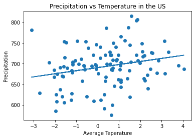

```python
# set x to temperature in North America
x = climate_dfs[5][:-2]['jan_temp_celsius']
# set y to precipitation in America
y = precipitation_df[9:]['United States']
plt.scatter(x=x, y=y)
plt.xlabel('Average Teperature')
plt.ylabel('Precipitation')
plt.title('Precipitation vs Temperature in the US')
#obtain m (slope) and b(intercept) of linear regression lineir
m, b = np.polyfit(x, y, 1)

#add linear regression line to scatterplot
plt.plot(x, m*x+b)
```

There is not much correlation that we can see from this graph. However, after running a regression line through it, we can see a positive correlation. However, this is not convincing enough so we will have to do some more analysis.

We are going to see if there is any upward trend between precipitation and temperature in the top increasing states (in terms of precipitation) and if there is any downward trend between precipitation and temperature in the bottom states (in terms of precipitation)

# Top Increasing Precipitation vs Temperature

Here we are going to plot the top states that have shown highest increase in precipitation in the US and we are going to plot them agains temperature. By doing this we can see if there is any trend.

If you want to learn more about subplots click [Subplots](https://www.tutorialspoint.com/how-to-make-two-plots-side-by-side-using-python).

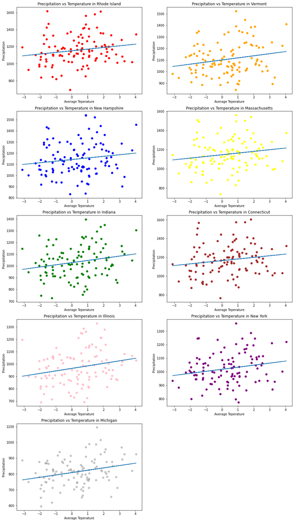

```python
# set the size of the plot to 14 width and 7 height
fig = plt.figure(figsize = (16, 30))

topStates = ['Rhode Island', 'Vermont', 'New Hampshire', 'Massachusetts', 'Indiana', 'Connecticut', 'Illinois', 'New York', 'Michigan']
colors = ['red', 'orange', 'blue', 'yellow', 'green', 'brown', 'pink', 'purple', '#aaaa']
# set x to temperature in North America
x = climate_dfs[5][:-2]['jan_temp_celsius']

i = 1
# go through all top states and plot precipitation vs temp for the 9 selected states
for state in topStates:
  # creating subplots to put side by side
  plt.subplot(5, 2, i) # row 5, col 2 index i
  y = precipitation_df[9:][state]
  plt.scatter(x=x, y=y, color=colors[i-1])
  plt.xlabel('Average Teperature')
  plt.ylabel('Precipitation')
  plt.title('Precipitation vs Temperature in {}'.format(state))
  #obtain m (slope) and b(intercept) of linear regression lineir
  m, b = np.polyfit(x, y, 1)
  #add linear regression line to scatterplot
  plt.plot(x, m*x+b)
  i += 1
plt.show()
```

We can see that some of the states have a very good correlation between their increase in precipitation and the temperature. Michigan, New York, Illinois and Indiana show a definite increase as temperature increases. However, states such as Connecticut, Massachusetts and New Hamshire do not show much correlation and their plots are very scattered meaning that even at lower temperatures we have gotten high precipitation readings.

One thing that however, they all have in common is that all of their regression lines are sloped upwards. Meaning that they all have at least a slight increase in precipitation when temperature increases.

# Most Decrease/Least Increase Precipitation vs Temperature

Here we are going to plot the bottom states that have shown the least increase or even a decrease in precipitation in the US and we are going to plot them agains temperature. By doing this we can see if there is any trend.

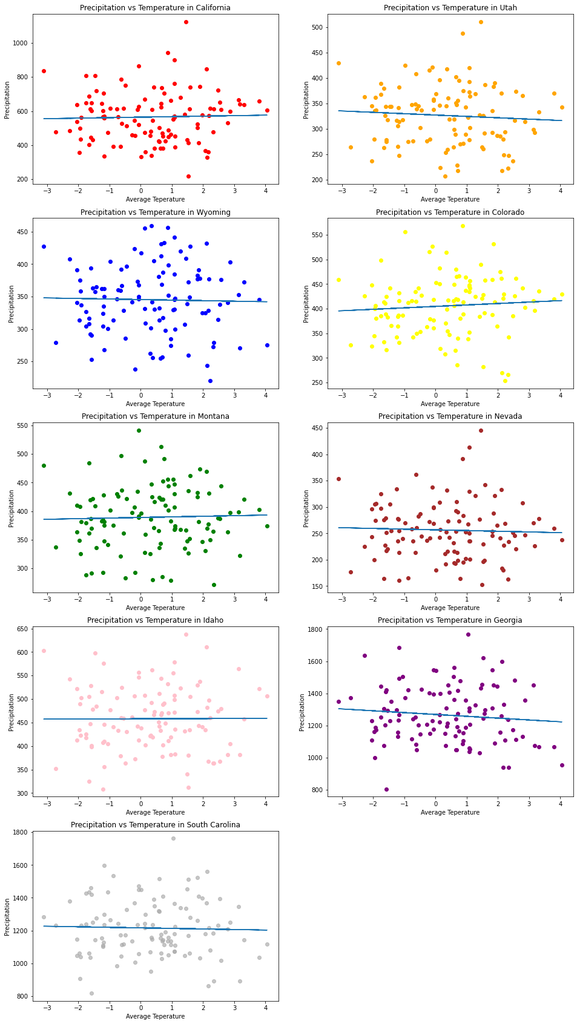

```python
# set the size of the plot to 14 width and 7 height
fig = plt.figure(figsize = (16, 30))

bottomStates = ['California', 'Utah', 'Wyoming', 'Colorado', 'Montana', 'Nevada', 'Idaho', 'Georgia', 'South Carolina']
colors = ['red', 'orange', 'blue', 'yellow', 'green', 'brown', 'pink', 'purple', '#aaaa']
# set x to temperature in North America
x = climate_dfs[5][:-2]['jan_temp_celsius']

i = 1
# go through all bottom states and plot precipitation vs temp for the 9 selected states
for state in bottomStates:
  # creating subplots to put side by side
  plt.subplot(5, 2, i) # row 5, col 2 index i
  y = precipitation_df[9:][state]
  plt.scatter(x=x, y=y, color=colors[i-1])
  plt.xlabel('Average Teperature')
  plt.ylabel('Precipitation')
  plt.title('Precipitation vs Temperature in {}'.format(state))
  #obtain m (slope) and b(intercept) of linear regression lineir
  m, b = np.polyfit(x, y, 1)
  #add linear regression line to scatterplot
  plt.plot(x, m*x+b)
  i += 1
plt.show()
```

Since, these states were mostly in the wester/central parts of the US and also these are the more dry states in the US. We can conclude that the temperature is not effecting drier regions of the country as much as it is effecting states that already had high precipitations.

# **Conclusion**

In this tutorial we have went over so many different aspects of climate change and precipitatoin. We have seen that climate change is not effecting every region of the world at the same rate. The degree of change depends on so many variables. The variables that we were able see was that, at regions closer to the equator, we had less change in the temperature. In contrast we had the most change in North America which is above the equator.

In this tutorial, we have used a series of plots and regression lines. Barplot and scatter plots were the two different types of plots we used. We also used regression lines and average line to make better sense of our data. For more resources and tutorials on what we used, we have included some links in the "Refernces" section.

**References:**

- Preciptitaion Data from the United States Environmental Protection Agency - https://www.epa.gov/climate-indicators/climate-change-indicators-us-and-global-precipitation
- Annual Global Temperature Averages - https://datahub.io/core/global-temp#data
- National Centers for Environmental Information, National Oceanic and Atmospheric Administration (NOAA) - https://www.ncdc.noaa.gov/cag/global/time-series/
- Scatter Plots - https://matplotlib.org/3.5.0/api/_as_gen/matplotlib.pyplot.scatter.html
- Linear Regression - https://realpython.com/linear-regression-in-python/
- *Which parts of the planet are warming the fastest, and why?* - https://climate.mit.edu/ask-mit/which-parts-planet-are-warming-fastest-and-why#:~:text=The%20earth's%20largest%20land%20masses,reflect%20energy%20from%20the%20sun.&text=For%20more%20than%20a%20century,labs%2C%20ships%2C%20and%20satellites.
- Barplot - https://matplotlib.org/3.5.0/api/_as_gen/matplotlib.pyplot.bar.html
- Dataframes and Arrays - https://www.geeksforgeeks.org/create-a-dataframe-from-a-numpy-array-and-specify-the-index-column-and-column-headers/
- Subplots - https://www.tutorialspoint.com/how-to-make-two-plots-side-by-side-using-python